# IODS course project

Antero Salminen

# Introduction to Open Data Science - Course Project

# About the project

*Write a short description about the course and add a link to your GitHub repository here. This is an R Markdown (.Rmd) file so you should use R Markdown syntax.*

This is course diary of the course Introduction to Open Data Science. My repository can be found here: [https://github.com/*anterogradinen*/IODS-project](https://github.com/anterogradinen/IODS-project)

```r
# This is a so-called "R chunk" where you can write R code.

date()
```

```
## [1] "Mon Nov 20 22:30:12 2023"
```

# Chapter 1

Assignment 1: Tasks and Instructions copied from Moodle.

1. DONE. Check that you have everything installed and created according to the instructions. You should have a GitHub repository, a course diary web page (also on GitHub, in a different address) and the IODS-project started on RStudio using the course templates. **(3 p)**
2. DONE. Open the file chapter1.Rmd located in your IODS-project folder with **RStudio**. Just write some of your thoughts about this course freely in the file, e.g., How are you feeling right now? What do you expect to learn? Where did you hear about the course?
   1. Feelings. I am excited of this course! I am already with one R-course but this course takes in consideration open data aspect which is really interesting and future skill.
   2. Expectations. I really hope that this and other R-course I have support my learning process to become starting data-analyst. Also the aspect of open data and its possibilities really inspires me.
   3. Where did I hear about this course? I have came across this course coupe of times but now I really have the possibility to participate to this.
3. Also reflect on your learning experiences with the **R for Health Data Science** book and the **Exercise Set 1**:
   1. How did it work as a “crash course” on modern R tools and using RStudio?
      1. I found the book very useful, because it introduced R and RStudio bit different than book “R for Data Science (2e)” by Wickham and Çetinkaya-Rundel ([https://r4ds.hadley.nz/](https://r4ds.hadley.nz/data-transform#columns)), which I have read previously during this autumn. Both books support each other.
      2. Although I felt that first five chapters in a one week was bit too much. (I am currently writing this after chapter 3.5.)
      3. First I wasn’t sure if the Excercise1-material was needed because the book provided the code which can be copy-pasted, but the exercise material saved lot of time when you did not have to download all the example data and copy-paste every example script.
   2. Which were your favorite topics?
      1. I have found chapters 3.3., 3.4. and 3.5. so far most useful. (I am currently writing this after chapter 3.5.)
   3. Which topics were most difficult?
      1. I think that that internalizing how to use group_by and summarise may take some time. Also ungrouping was something I need to return later on.
   4. Some other comments on the book and our new approach of getting started with R Markdown etc.? (All this is just “warmup” to get well started and learn also the technical steps needed each week in Moodle, that is, submit and review.
   5. We will start more serious work next week! You can already look at the next topic in Moodle and begin working with the Exercise Set 2...)
4. **DONE** Also add in the file a link to your GitHub repository (that you created earlier): https://github.com/anterogradinen/IODS-project
5. You can immediately start to learn the basics of the **R Markdown** syntax that we will use for writing the exercise reports: Try, for example, highlighting parts of your text, adding some headers, lists, links etc. *Hint:* Use the R Markdown Reference Guide or cheatsheet (both found from the RStudio Help). This is an excellent **quick (1 min) tour** of R Markdown, please watch: https://rmarkdown.rstudio.com/lesson-1.html
6. DONE. Remember to save your chapter1.Rmd file. **(5 p)**
7. **DONE** Open the index.Rmd file with RStudio. At the beginning of the file, in the YAML options below the ‘title’ option, add the following option: **author: “Your Name”**. Save the file and “knit” the document (there’s a button for that) as an HTML page. This will also update the index.html file. **(2 p)**
8. **DONE.** (This point added in 2022 - let’s hope it works similarly in 2023!)  
   To make the connection between RStudioand GitHub as smooth as possible, you should create a **Personal Access Token (PAT)**.

   The shortest way to proceed is to follow the steps below. (Source: https://happygitwithr.com/https-pat.html)

   Execute these R commands in the RStudio Console (below the Editor):

   ```
   install.packages("usethis")
   usethis::create_github_token()
   ```

   GitHub website will open in your browser. Log in with your GitHub credentials.
   - Write a **Note** in the box, for example “IODS Project”.
   - Select an **Expiration** time for your PAT, e.g., 50 days.
   - The pre-selected **scopes** “repo”, “workflow”, “gist”, and “user” are OK.
   - Press **“Generate token”** and **copy the generated PAT to your clipboard**. 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

   Return to RStudio and continue in the Console:

   ```
   gitcreds::gitcreds_set()
   ```

   - WAIT until a prompt “Enter password or token:” appears.
   - Paste your PAT to the prompt and press Enter.

   Now you should be able to work with GitHub, i.e., push and pull from RStudio. Congrats!! **(5 p)**
9. Upload the changes to GitHub (the version control platform) from RStudio.  
   There are a few phases **(don’t worry: all this will become an easy routine for you very soon!)**:
10. DEMO
    - First, select the “Git” tab in the upper right corner of RStudio. You will see a list of modified files.
    - Select “Commit”. It will open a new “Review Changes” window showing more detailed information of the changes you have made in each file since the previous version.
    - Tick the box in the front of each file *(be patient, it takes some time for the check to appear).*
    - Write a small **commit message** (there’s a box for that) that describes your changes briefly. After this task is completed (not yet), both the changes and the message will be seen on GitHub. (**Note:** It is useful to make commits often and even on small changes. **Commits are at the heart of the version control system, as a single commit represents a single version of the file.**)
    - Press “Commit”. (RStudio uses Git to implement the changes included in the commit.)
    - Press “Push”. (RStudio uses Git to upload the changes to your GitHub repository.)
    - Now you can close the “Review Changes” window of RStudio. Good job!! **(5 p)**
11. *After a few moments*, go to your GitHub repository at  
    [https://github.com/*anterogradinen*/IODS-project](https://github.com/anterogradinen/IODS-project)  
    to see what has changed *(please be patient and refresh the page)*.  
    Also visit your **course diary** that has been automatically been updated at  
    https://anterogradinen.github.io/IODS-project/ and make sure you see the changes there as well.

**After completing the tasks above you are ready to submit your Assignment for the review (using the Moodle Workshop below).** **Have the two links (your GitHub repository and your course diary) ready! Remember to get back there when the Review phase begins (see course schedule).**

Have fun and don’t be afraid to ask for help using the Moodle discussion forum.

# Chapter 2: Assignment 2: Analysis (max 15 points)

This weeks assignment was a tough one! Also I had last minute tech issues with knitting. Apologies if my code and text is difficult to read. I tried to use code chunks (like in the “date()” -part) in parts 1-5 but could not knit whole thing so the code is there in a regular text.

First I read the material and then started doing exercises and only then doing Assignment 2 itself. I feel that this was not the most time efficient way to learn. But this weeks learning curve was quite steep! I think I have learned quite lot about linear models this week. Also I found the data and data wrangling exercise really useful regarding my own research topic.

Nevertheless I think I need to read the material again because I am not 100% confident when looking model summaries and tables. I also fear that if I do not internalise these topics well enough, the rest of the course will be torment or I can drop out.

```r
date()
```

```
## [1] "Mon Nov 20 22:30:12 2023"
```

# 1. Read the data & describe the dataset briefly

students2014_data <- read.table(“https://raw.githubusercontent.com/KimmoVehkalahti/Helsinki-Open-Data-Science/master/datasets/learning2014.txt”, sep = “,”, header = TRUE)

view(students2014_data)

**describe the dataset briefly**

glimpse(students2014_data)

166 respondents: 166 rows and 7 columns

ff_glimpse(students2014_data)

**Comments**

- age median is 22.0 and mean is 25.5.
- youngest 17 year old and oldest 55 year old,
- points mean 22.7, 23 median, min 7.0 and max 33.00.

Other variables:

- attitude (mean 3.1),
- deep approach (mean 3.7),
- stategic approach (mean 3.1) and
- surface approach (mean 2.8)

students2014_data |> count(gender)

- gender split: 110 female (66.3%), 56 male (33.7%)

# 2. Graphical overview

Show a graphical overview of the data and show summaries of the variables in the data. Describe and interpret the outputs, commenting on the distributions of the variables and the relationships between them.

library(GGally) library(ggplot2)

“create a plot matrix with ggpairs()”

p <- ggpairs(students2014_data, mapping = aes(col = gender, alpha = 0.3), lower = list(combo = wrap(“facethist”, bins = 20)))

“draw the plot”

p

summaries about the variables stated above in part 1.

# 3. Regression model

- Choose three variables as explanatory variables and fit a regression model where exam points is the target (dependent, outcome) variable. Show a summary of the fitted model and comment and interpret the results.
- Explain and interpret the statistical test related to the model parameters. If an explanatory variable in your model does not have a statistically significant relationship with the target variable, remove the variable from the model and fit the model again without it. **(0-4 points)**
- Explanatory variables (selected based on correlation matrix): 1) Global attitude toward statistics, 2) gender and 3) strategic approach to learning.
- Dependent, outcome: Exam points

**create a regression model with multiple explanatory variables**

my_model3 <- lm(points ~ attitude + stra + gender, data = students2014_data)

“print out a summary of the model”

summary(my_model3)

Explain and interpret the statistical test related to the model parameters.

- Attitude has statistically significant connection to points. In this model it’s slope is 3.5. Meaning that positive attitude to statistics had connection to higher points (one point increase in attitude average increased 3.5 of total points during course).
- Strategic approach had positive connection to points, but statistically this connection was not significant.
- Males had negative connection to points, but statistically this connection was not significant.
- Adjusted R-squared is low (0.1904), meaning that the model does not describe data well.
- Trying to make better model: If an explanatory variable in your model does not have a statistically significant relationship with the target variable, remove the variable from the model and fit the model again without it.

my_model4 <- lm(points ~ attitude, data = students2014_data) summary(my_model4)

Comments about my_model4:

- no mentionable changes in model. Adjusted R-squared is still low (0.1804)

# 4. explaining the relationship between explanatory variables and the target variable

“Using a summary of your fitted model, explain the relationship between the chosen explanatory variables and the target variable (interpret the model parameters).”

Explain and interpret the multiple R-squared of the model. **(0-3 points)**

qplot(attitude, points, data = students2014_data) + geom_smooth(method = “lm”)

summary(my_model3)

Explain and interpret the multiple R-squared of the model.

- Based on this model: 20% of the variation of points are explained by these selected variables
- I also add my observation from task 3 above:
- Attitude has statistically significant connection to points. In this model it’s slope is 3.5. Meaning that positive attitude to statistics had connection to higher points (one point increase in attitude average increased 3.5 of total points during course).
- Strategic approach had positive connection to points, but statistically this connection was not significant.
- Males had negative connection to points, but statistically this connection was not significant.
- Adjusted R-squared is low (0.1904), meaning that the model does not describe data well.

# 5. Diagnostic plots

Produce the following diagnostic plots: Residuals vs Fitted values, Normal QQ-plot and Residuals vs Leverage.

Explain the assumptions of the model and interpret the validity of those assumptions based on the diagnostic plots. **(0-3 points)**

my_model3 <- lm(points ~ attitude + gender, data = students2014_data) plot(my_model3, which = c(1,2,5))

## Assignment 3

### Analysis

```r
date() #testing does the code chunk work (had issues with assignment 2)
```

```
## [1] "Mon Nov 20 22:30:13 2023"
```

As mentioned above, I had some tech issues with last knitting and code chunk. As I did with last week’s assignment, I did have had difficult time also with this weeks material and assignment. Unfortunately I did not manage to do every task required. I am bit worried will I fall behind in this course. Nevertheless I found the exercise material really interesting.

### 2

Read the joined student alcohol consumption data into R either from your local folder (if you completed the Data wrangling part) or from this url (in case you got stuck with the Data wrangling part):

https://raw.githubusercontent.com/KimmoVehkalahti/Helsinki-Open-Data-Science/master/datasets/alc.csv

(In the above linked file, the column separator is a comma and the first row includes the column names). Print out the names of the variables in the data and describe the data set briefly, assuming the reader has no previous knowledge of it. There is information related to the data here. (0-1 point)

```r
library(dplyr)
library(tidyr)
library(finalfit)
library(tidyverse)
alc3 <- read.table("https://raw.githubusercontent.com/KimmoVehkalahti/Helsinki-Open-Data-Science/master/datasets/alc.csv", sep = ",", header = T)

glimpse(alc3)
```

```
## Rows: 370
## Columns: 35
## $ school     <chr> "GP", "GP", "GP", "GP", "GP", "GP", "GP", "GP", "GP", "GP",…
## $ sex        <chr> "F", "F", "F", "F", "F", "M", "M", "F", "M", "M", "F", "F",…
## $ age        <int> 18, 17, 15, 15, 16, 16, 16, 17, 15, 15, 15, 15, 15, 15, 15,…
## $ address    <chr> "U", "U", "U", "U", "U", "U", "U", "U", "U", "U", "U", "U",…
## $ famsize    <chr> "GT3", "GT3", "LE3", "GT3", "GT3", "LE3", "LE3", "GT3", "LE…
## $ Pstatus    <chr> "A", "T", "T", "T", "T", "T", "T", "A", "A", "T", "T", "T",…
## $ Medu       <int> 4, 1, 1, 4, 3, 4, 2, 4, 3, 3, 4, 2, 4, 4, 2, 4, 4, 3, 3, 4,…
## $ Fedu       <int> 4, 1, 1, 2, 3, 3, 2, 4, 2, 4, 4, 1, 4, 3, 2, 4, 4, 3, 2, 3,…
## $ Mjob       <chr> "at_home", "at_home", "at_home", "health", "other", "servic…
## $ Fjob       <chr> "teacher", "other", "other", "services", "other", "other", …
## $ reason     <chr> "course", "course", "other", "home", "home", "reputation", …
## $ guardian   <chr> "mother", "father", "mother", "mother", "father", "mother",…
## $ traveltime <int> 2, 1, 1, 1, 1, 1, 1, 2, 1, 1, 1, 3, 1, 2, 1, 1, 1, 3, 1, 1,…
```

[output cut: 22 more lines]

### 3

The purpose of your analysis is to study the relationships between high/low alcohol consumption and some of the other variables in the data. To do this, choose 4 interesting variables in the data and for each of them, present your personal hypothesis about their relationships with alcohol consumption. (0-1 point)

For this excercise I study relationship between high and low alcohol consumption gender, education level of parents, and motivation to take higher education.

I am interested to look wheter there is relationship between student’s motivation to take higher education and education level of parents to alcohol consumption.

Variables are following (described in: http://www.archive.ics.uci.edu/dataset/320/student+performance)

7 Medu - mother’s education (numeric: 0 - none, 1 - primary education (4th grade), 2 — 5th to 9th grade, 3 — secondary education or 4 — higher education)

8 Fedu - father’s education (numeric: 0 - none, 1 - primary education (4th grade), 2 — 5th to 9th grade, 3 — secondary education or 4 — higher education)

17 famsup - family educational support (binary: yes or no)

21 higher - wants to take higher education (binary: yes or no)

My personal hypothesis about these variables is that would have low (if any) negative correlation:the higher family’s education level and student’s “education motivation” the lower alchohol consumption.

I also computed mean education level based on both parents education level.

### 4

Numerically and graphically explore the distributions of your chosen variables and their relationships with alcohol consumption (use for example cross-tabulations, bar plots and box plots).

Comment on your findings and compare the results of your exploration to your previously stated hypotheses. (0-5 points)

First we look how much alcohol is used in different genders. We see that data have 70 male students with high use of alcohol and female students 41.

While looking boxplots of parents’ education and high use of alcohol consumption, I do not see much anything of noteworthy. Father’s education level median is bit lower with male students with high alcohol consumption. But father’s education level median was also lower with female student with low alcohol consumption. I think that boxplot is not the best graphic with this data.

This observations do not really support my hypothesis (but do not refute it necessarily). I also note that would analyze both parents’ education level and alcohol consumption bit better than with mean grade. Unfortunately I ran out of time with this assignment. :(

```r
### bar plots ###

# A plot of alcohol use with gender
alc3 |>
  group_by(sex) |>
  count(alc3$high_use)
```

```
## # A tibble: 4 × 3
## # Groups:   sex [2]
##   sex   `alc3$high_use`     n
##   <chr> <lgl>           <int>
## 1 F     FALSE             154
## 2 F     TRUE               41
## 3 M     FALSE             105
## 4 M     TRUE               70
```

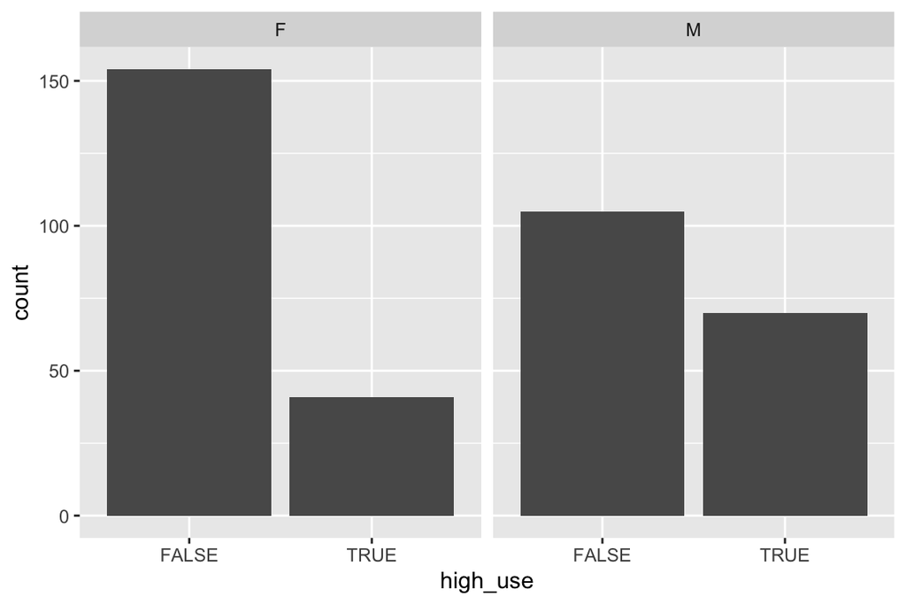

```r
g1 <- ggplot(data = alc3, aes(x = high_use))
g1 + geom_bar() + facet_wrap("sex")
```

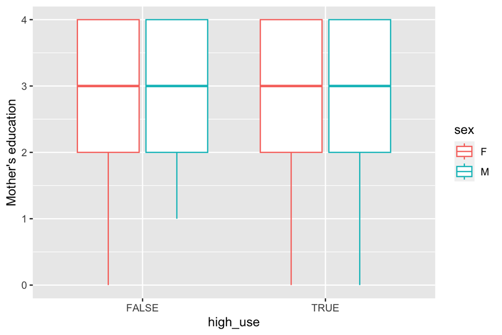

```r
### box plots ###

# a plot of high_use and mother's education
g1 <- ggplot(alc3, aes(x = high_use, y = Medu, col = sex))
g1 + geom_boxplot() + ylab("Mother's education")
```

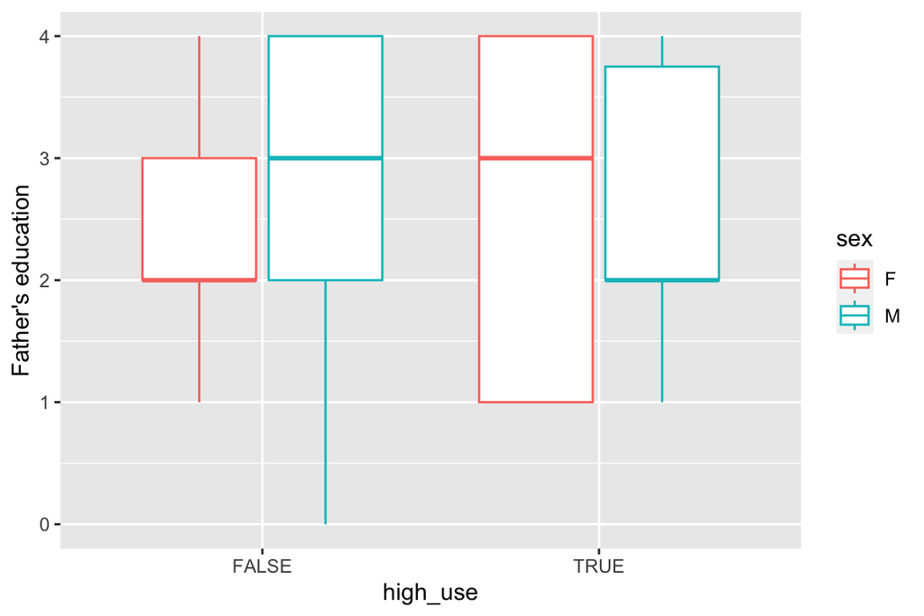

```r
# a plot of high_use and father's education
g2 <- ggplot(alc3, aes(x = high_use, y = Fedu, col = sex))
g2 + geom_boxplot() + ylab("Father's education")
```

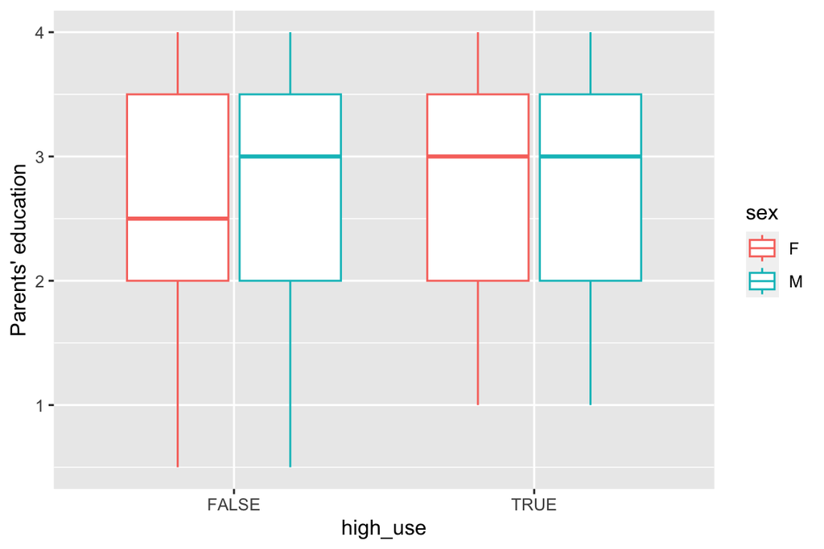

```r
# a plot of high_use and parents' education (Pedu, mean of Medu ja Fedu)
alc3 <- mutate(alc3, Pedu = ((Medu + Fedu) / 2))
g3 <- ggplot(alc3, aes(x = high_use, y = Pedu, col = sex))
g3 + geom_boxplot() + ylab("Parents' education")
```

### 5

Use logistic regression to statistically explore the relationship between your chosen variables and the binary high/low alcohol consumption variable as the target variable. Present and interpret a summary of the fitted model. Present and interpret the coefficients of the model as odds ratios and provide confidence intervals for them. Interpret the results and compare them to your previously stated hypothesis.

Hint: If your model includes factor variables, see for example the RHDS book or the first answer of this stack exchange thread on how R treats and how you should interpret these variables in the model output (or use some other resource to study this). (0-5 points)

### 6

Using the variables which, according to your logistic regression model, had a statistical relationship with high/low alcohol consumption, explore the predictive power of you model. Provide a 2x2 cross tabulation of predictions versus the actual values and optionally display a graphic visualizing both the actual values and the predictions. Compute the total proportion of inaccurately classified individuals (= the training error) and comment on all the results. Compare the performance of the model with performance achieved by some simple guessing strategy. (0-3 points)

Bonus: Perform 10-fold cross-validation on your model. Does your model have better test set performance (smaller prediction error using 10-fold cross-validation) compared to the model introduced in the Exercise Set (which had about 0.26 error). Could you find such a model? (0-2 points to compensate any loss of points from the above exercises)

Super-Bonus: Perform cross-validation to compare the performance of different logistic regression models (= different sets of predictors). Start with a very high number of predictors and explore the changes in the training and testing errors as you move to models with less predictors. Draw a graph displaying the trends of both training and testing errors by the number of predictors in the model. (0-4 points to compensate any loss of points from the above exercises)

After completing all the phases above you are ready to submit your Assignment for the review (using the Moodle Workshop below). Have the two links (your GitHub repository and your course diary) ready!

(more chapters to be added similarly as we proceed with the course!)